# Part 1 - Exploratory Analysis of Loan Data from Prosper

### by Tumininu Adesimbo Sosanya

## Introduction

This Loan Data Set from Prosper contains 113,937 loans with 81 variables on each loan, including loan amount, borrower rate (or interest rate), current loan status, borrower income, and many others.

### Preliminary Wrangling

```python
# import all packages and set plots to be embedded inline

import numpy as np
import pandas as pd
import matplotlib.pyplot as plt
import seaborn as sns

%matplotlib inline
```

Load the dataset into a pandas dataframe, print statistics by describing its properties through the following questions below.

```python
# load the data into pandas dataframe and set to variable df

df = pd.read_csv('prosperLoanData.csv')
```

```python
# view the first 5 rows of the dataset

df.head()
```

|  | ListingKey | ListingNumber | ListingCreationDate | CreditGrade | Term | LoanStatus | ClosedDate | BorrowerAPR | BorrowerRate | LenderYield | ... | LP_ServiceFees | LP_CollectionFees | LP_GrossPrincipalLoss | LP_NetPrincipalLoss | LP_NonPrincipalRecoverypayments | PercentFunded | Recommendations | InvestmentFromFriendsCount | InvestmentFromFriendsAmount | Investors |
| --- | --- | --- | --- | --- | --- | --- | --- | --- | --- | --- | --- | --- | --- | --- | --- | --- | --- | --- | --- | --- | --- |
| 0 | 1021339766868145413AB3B | 193129 | 2007-08-26 19:09:29.263000000 | C | 36 | Completed | 2009-08-14 00:00:00 | 0.16516 | 0.1580 | 0.1380 | ... | -133.18 | 0.0 | 0.0 | 0.0 | 0.0 | 1.0 | 0 | 0 | 0.0 | 258 |
| 1 | 10273602499503308B223C1 | 1209647 | 2014-02-27 08:28:07.900000000 | NaN | 36 | Current | NaN | 0.12016 | 0.0920 | 0.0820 | ... | 0.00 | 0.0 | 0.0 | 0.0 | 0.0 | 1.0 | 0 | 0 | 0.0 | 1 |
| 2 | 0EE9337825851032864889A | 81716 | 2007-01-05 15:00:47.090000000 | HR | 36 | Completed | 2009-12-17 00:00:00 | 0.28269 | 0.2750 | 0.2400 | ... | -24.20 | 0.0 | 0.0 | 0.0 | 0.0 | 1.0 | 0 | 0 | 0.0 | 41 |
| 3 | 0EF5356002482715299901A | 658116 | 2012-10-22 11:02:35.010000000 | NaN | 36 | Current | NaN | 0.12528 | 0.0974 | 0.0874 | ... | -108.01 | 0.0 | 0.0 | 0.0 | 0.0 | 1.0 | 0 | 0 | 0.0 | 158 |
| 4 | 0F023589499656230C5E3E2 | 909464 | 2013-09-14 18:38:39.097000000 | NaN | 36 | Current | NaN | 0.24614 | 0.2085 | 0.1985 | ... | -60.27 | 0.0 | 0.0 | 0.0 | 0.0 | 1.0 | 0 | 0 | 0.0 | 20 |

5 rows × 81 columns

```python
# view 10 random samples of the data set

df.sample(10)
```

|  | ListingKey | ListingNumber | ListingCreationDate | CreditGrade | Term | LoanStatus | ClosedDate | BorrowerAPR | BorrowerRate | LenderYield | ... | LP_ServiceFees | LP_CollectionFees | LP_GrossPrincipalLoss | LP_NetPrincipalLoss | LP_NonPrincipalRecoverypayments | PercentFunded | Recommendations | InvestmentFromFriendsCount | InvestmentFromFriendsAmount | Investors |
| --- | --- | --- | --- | --- | --- | --- | --- | --- | --- | --- | --- | --- | --- | --- | --- | --- | --- | --- | --- | --- | --- |
| 98659 | 868D36017032465348C18AC | 1184901 | 2014-02-03 18:04:16.373000000 | NaN | 36 | Current | NaN | 0.19029 | 0.1535 | 0.1435 | ... | 0.00 | 0.00 | 0.0 | 0.0 | 0.0 | 1.0 | 0 | 0 | 0.00 | 1 |
| 14183 | 18C43391632659397409C34 | 148900 | 2007-06-08 08:39:14.293000000 | AA | 36 | Completed | 2009-12-15 00:00:00 | 0.12198 | 0.1150 | 0.1100 | ... | -70.79 | 0.00 | 0.0 | 0.0 | 0.0 | 1.0 | 1 | 1 | 60.32 | 179 |
| 30796 | 5EBB35900405833027F749A | 920197 | 2013-09-22 11:36:19.360000000 | NaN | 36 | Current | NaN | 0.18479 | 0.1485 | 0.1385 | ... | -27.70 | 0.00 | 0.0 | 0.0 | 0.0 | 1.0 | 0 | 0 | 0.00 | 91 |
| 89414 | 4C783535558524752874DE8 | 548040 | 2012-01-02 07:15:08.907000000 | NaN | 36 | Current | NaN | 0.23990 | 0.2024 | 0.1924 | ... | -146.68 | 0.00 | 0.0 | 0.0 | 0.0 | 1.0 | 0 | 0 | 0.00 | 8 |
| 40147 | 46253542661149082479328 | 574936 | 2012-04-03 08:32:59.333000000 | NaN | 36 | Current | NaN | 0.17359 | 0.1449 | 0.1349 | ... | -41.10 | 0.00 | 0.0 | 0.0 | 0.0 | 1.0 | 0 | 0 | 0.00 | 16 |
| 47594 | 9D273570176448343E532CD | 713549 | 2013-02-16 14:15:35.823000000 | NaN | 36 | Current | NaN | 0.21945 | 0.1824 | 0.1724 | ... | -87.61 | 0.00 | 0.0 | 0.0 | 0.0 | 1.0 | 0 | 0 | 0.00 | 176 |
| 101909 | D393359690726799603AE46 | 1081922 | 2013-12-15 22:11:08.537000000 | NaN | 36 | Current | NaN | 0.16732 | 0.1314 | 0.1214 | ... | -25.19 | 0.00 | 0.0 | 0.0 | 0.0 | 1.0 | 0 | 0 | 0.00 | 1 |
| 15484 | 9D4B3517953031770D7753B | 509575 | 2011-06-03 10:12:09.363000000 | NaN | 36 | Completed | 2011-12-13 00:00:00 | 0.35643 | 0.3199 | 0.3099 | ... | -12.45 | 0.00 | 0.0 | 0.0 | 0.0 | 1.0 | 0 | 0 | 0.00 | 29 |
| 73055 | F2A433658826598724D9C51 | 25253 | 2006-07-18 08:47:38.910000000 | A | 36 | Completed | 2009-06-10 00:00:00 | 0.13554 | 0.1285 | 0.1235 | ... | -31.43 | -40.54 | 0.0 | 0.0 | 0.0 | 1.0 | 0 | 0 | 0.00 | 47 |
| 66219 | C4873549951344388F7929A | 595722 | 2012-06-03 17:18:41.753000000 | NaN | 36 | Current | NaN | 0.28851 | 0.2499 | 0.2399 | ... | -159.54 | 0.00 | 0.0 | 0.0 | 0.0 | 1.0 | 0 | 0 | 0.00 | 109 |

10 rows × 81 columns

```python
# more information such as number of entries, missing values, incorrect data types of the dataset

df.info()
```

```
<class 'pandas.core.frame.DataFrame'>
RangeIndex: 113937 entries, 0 to 113936
Data columns (total 81 columns):
 #   Column                               Non-Null Count   Dtype
---  ------                               --------------   -----
 0   ListingKey                           113937 non-null  object
 1   ListingNumber                        113937 non-null  int64
 2   ListingCreationDate                  113937 non-null  object
 3   CreditGrade                          28953 non-null   object
 4   Term                                 113937 non-null  int64
 5   LoanStatus                           113937 non-null  object
 6   ClosedDate                           55089 non-null   object
 7   BorrowerAPR                          113912 non-null  float64
 8   BorrowerRate                         113937 non-null  float64
 9   LenderYield                          113937 non-null  float64
```

[output cut: 73 more lines]

```python
# no of rows and columns (113937 rows, 81 columns)

df.shape
```

```
(113937, 81)
```

```python
# data types of the columns

df.dtypes
```

```
ListingKey                      object
ListingNumber                    int64
ListingCreationDate             object
CreditGrade                     object
Term                             int64
                                ...
PercentFunded                  float64
Recommendations                  int64
InvestmentFromFriendsCount       int64
InvestmentFromFriendsAmount    float64
Investors                        int64
Length: 81, dtype: object
```

```python
# descriptive statistics for numeric variables

df.describe()
```

|  | ListingNumber | Term | BorrowerAPR | BorrowerRate | LenderYield | EstimatedEffectiveYield | EstimatedLoss | EstimatedReturn | ProsperRating (numeric) | ProsperScore | ... | LP_ServiceFees | LP_CollectionFees | LP_GrossPrincipalLoss | LP_NetPrincipalLoss | LP_NonPrincipalRecoverypayments | PercentFunded | Recommendations | InvestmentFromFriendsCount | InvestmentFromFriendsAmount | Investors |
| --- | --- | --- | --- | --- | --- | --- | --- | --- | --- | --- | --- | --- | --- | --- | --- | --- | --- | --- | --- | --- | --- |
| count | 1.139370e+05 | 113937.000000 | 113912.000000 | 113937.000000 | 113937.000000 | 84853.000000 | 84853.000000 | 84853.000000 | 84853.000000 | 84853.000000 | ... | 113937.000000 | 113937.000000 | 113937.000000 | 113937.000000 | 113937.000000 | 113937.000000 | 113937.000000 | 113937.000000 | 113937.000000 | 113937.000000 |
| mean | 6.278857e+05 | 40.830248 | 0.218828 | 0.192764 | 0.182701 | 0.168661 | 0.080306 | 0.096068 | 4.072243 | 5.950067 | ... | -54.725641 | -14.242698 | 700.446342 | 681.420499 | 25.142686 | 0.998584 | 0.048027 | 0.023460 | 16.550751 | 80.475228 |
| std | 3.280762e+05 | 10.436212 | 0.080364 | 0.074818 | 0.074516 | 0.068467 | 0.046764 | 0.030403 | 1.673227 | 2.376501 | ... | 60.675425 | 109.232758 | 2388.513831 | 2357.167068 | 275.657937 | 0.017919 | 0.332353 | 0.232412 | 294.545422 | 103.239020 |
| min | 4.000000e+00 | 12.000000 | 0.006530 | 0.000000 | -0.010000 | -0.182700 | 0.004900 | -0.182700 | 1.000000 | 1.000000 | ... | -664.870000 | -9274.750000 | -94.200000 | -954.550000 | 0.000000 | 0.700000 | 0.000000 | 0.000000 | 0.000000 | 1.000000 |
| 25% | 4.009190e+05 | 36.000000 | 0.156290 | 0.134000 | 0.124200 | 0.115670 | 0.042400 | 0.074080 | 3.000000 | 4.000000 | ... | -73.180000 | 0.000000 | 0.000000 | 0.000000 | 0.000000 | 1.000000 | 0.000000 | 0.000000 | 0.000000 | 2.000000 |
| 50% | 6.005540e+05 | 36.000000 | 0.209760 | 0.184000 | 0.173000 | 0.161500 | 0.072400 | 0.091700 | 4.000000 | 6.000000 | ... | -34.440000 | 0.000000 | 0.000000 | 0.000000 | 0.000000 | 1.000000 | 0.000000 | 0.000000 | 0.000000 | 44.000000 |
| 75% | 8.926340e+05 | 36.000000 | 0.283810 | 0.250000 | 0.240000 | 0.224300 | 0.112000 | 0.116600 | 5.000000 | 8.000000 | ... | -13.920000 | 0.000000 | 0.000000 | 0.000000 | 0.000000 | 1.000000 | 0.000000 | 0.000000 | 0.000000 | 115.000000 |
| max | 1.255725e+06 | 60.000000 | 0.512290 | 0.497500 | 0.492500 | 0.319900 | 0.366000 | 0.283700 | 7.000000 | 11.000000 | ... | 32.060000 | 0.000000 | 25000.000000 | 25000.000000 | 21117.900000 | 1.012500 | 39.000000 | 33.000000 | 25000.000000 | 1189.000000 |

8 rows × 61 columns

```python
# no of unique values in the LoanStatus column

df['LoanStatus'].nunique()
```

```
12
```

```python
# unique values of LoanStatus

df['LoanStatus'].unique()
```

```
array(['Completed', 'Current', 'Past Due (1-15 days)', 'Defaulted',
       'Chargedoff', 'Past Due (16-30 days)', 'Cancelled',
       'Past Due (61-90 days)', 'Past Due (31-60 days)',
       'Past Due (91-120 days)', 'FinalPaymentInProgress',
       'Past Due (>120 days)'], dtype=object)
```

In the above unique values for LoanStatus, we would notice the frequent occurence of 'Past Due' unlike the other values such as 'completed', 'current', 'FinalPaymentInProgress' which are single values. So, let's categorize all the past due loan status as generally past due, then, check again for the output.

```python
# Categorize all the past due into a single past due value

df.LoanStatus = df.LoanStatus.replace(['Past Due (1-15 days)',
                'Past Due (16-30 days)', 'Past Due (61-90 days)',
                'Past Due (31-60 days)', 'Past Due (91-120 days)',
                'Past Due (>120 days)'], 'PastDue')
```

```python
# Check to see if the 'Past due' values have been changed

df['LoanStatus'].unique()
```

```
array(['Completed', 'Current', 'PastDue', 'Defaulted', 'Chargedoff',
       'Cancelled', 'FinalPaymentInProgress'], dtype=object)
```

```python
# Total number of missing values

sum(df.isna().sum())
```

```
1364086
```

### What is the struture of your dataset?

There are 113,937 loans in the dataset with total number of missing values to be 136,4086.

This dataset contains 81 features of these loans (loan amount, borrower rate, current loan status, borrower income and many more).

Most varibales are numeric in nature, but we have 'IncomeVerifiable', 'CurrentlyInGroup', 'IsBorrowerHomeowner' which are boolean(also qualitative), and 17 objects (also qualitative).

ProsperRiskScore variable is ordinal as it is an ordered factor variable with following levels: Worse (Highest Risk) ----> Best(Lowest Risk)

### What are the main features of interest in your dataset?

I am most interested in figuring out what features are best in predicting the borrower rate of a loan and features that affect loan status.

### What features in the dataset do you think will help support your investigation into your feature(s) of interest?

There are so many features that can support my investigation but I would focus more on 'ProsperRiskScore', 'BorrowersEmploymentStatus' and 'StatedIncomeLevel' as I am of the opinion that these factors can influence the 'BorrowersRate' and also be a stong determinant for the 'LoanStatus'

We will do some more cleaning here.

```python
# extract the date only in the 'ClosedDate' column

df['ClosedDate'] = pd.to_datetime(df['ClosedDate'])
```

```python
# view random samples of the dataset

df.sample(5)
```

|  | ListingKey | ListingNumber | ListingCreationDate | CreditGrade | Term | LoanStatus | ClosedDate | BorrowerAPR | BorrowerRate | LenderYield | ... | LP_ServiceFees | LP_CollectionFees | LP_GrossPrincipalLoss | LP_NetPrincipalLoss | LP_NonPrincipalRecoverypayments | PercentFunded | Recommendations | InvestmentFromFriendsCount | InvestmentFromFriendsAmount | Investors |
| --- | --- | --- | --- | --- | --- | --- | --- | --- | --- | --- | --- | --- | --- | --- | --- | --- | --- | --- | --- | --- | --- |
| 110346 | D3643604649445182CEB6A8 | 1194199 | 2014-03-03 14:04:28.183000000 | NaN | 36 | Current | NaT | 0.12016 | 0.0920 | 0.0820 | ... | 0.00 | 0.0 | 0.00 | 0.0 | 0.0 | 1.0 | 0 | 0 | 0.0 | 1 |
| 80542 | 479D3546429176380151451 | 590140 | 2012-05-17 11:44:44.117000000 | NaN | 36 | Completed | 2013-11-01 | 0.15538 | 0.1270 | 0.1170 | ... | -210.67 | 0.0 | 0.00 | 0.0 | 0.0 | 1.0 | 0 | 0 | 0.0 | 376 |
| 77059 | 555E3421650759952A6BAB7 | 340300 | 2008-05-28 07:08:16.617000000 | C | 36 | Completed | 2010-12-22 | 0.17018 | 0.1485 | 0.1385 | ... | -94.50 | 0.0 | 0.00 | 0.0 | 0.0 | 1.0 | 0 | 0 | 0.0 | 175 |
| 76498 | 6F113590662565124932C61 | 951965 | 2013-10-11 14:48:33.180000000 | NaN | 60 | Current | NaT | 0.19681 | 0.1730 | 0.1630 | ... | -49.74 | 0.0 | 0.00 | 0.0 | 0.0 | 1.0 | 0 | 0 | 0.0 | 168 |
| 110761 | 61B533737872326310E036E | 60073 | 2006-11-10 16:58:01.360000000 | HR | 36 | Chargedoff | 2008-10-20 | 0.23880 | 0.2200 | 0.2150 | ... | -6.06 | 0.0 | 584.89 | 584.9 | 0.0 | 1.0 | 0 | 0 | 0.0 | 21 |

5 rows × 81 columns

```python
# no of mising data in the 'ClosedDate' column

df.ClosedDate.isna().sum()
```

```
58848
```

```python
# Extract features of interest from the main dataset

df1 = df[['ClosedDate','BorrowerRate','ProsperScore','LoanStatus','StatedMonthlyIncome', 'EmploymentStatus']]
```

```python
# view the first 5 rows of the new dataframe

df1.head()
```

|  | ClosedDate | BorrowerRate | ProsperScore | LoanStatus | StatedMonthlyIncome | EmploymentStatus |
| --- | --- | --- | --- | --- | --- | --- |
| 0 | 2009-08-14 | 0.1580 | NaN | Completed | 3083.333333 | Self-employed |
| 1 | NaT | 0.0920 | 7.0 | Current | 6125.000000 | Employed |
| 2 | 2009-12-17 | 0.2750 | NaN | Completed | 2083.333333 | Not available |
| 3 | NaT | 0.0974 | 9.0 | Current | 2875.000000 | Employed |
| 4 | NaT | 0.2085 | 4.0 | Current | 9583.333333 | Employed |

```python
# more information about te new dataset

df1.info()
```

```
<class 'pandas.core.frame.DataFrame'>
RangeIndex: 113937 entries, 0 to 113936
Data columns (total 6 columns):
 #   Column               Non-Null Count   Dtype
---  ------               --------------   -----
 0   ClosedDate           55089 non-null   datetime64[ns]
 1   BorrowerRate         113937 non-null  float64
 2   ProsperScore         84853 non-null   float64
 3   LoanStatus           113937 non-null  object
 4   StatedMonthlyIncome  113937 non-null  float64
 5   EmploymentStatus     111682 non-null  object
dtypes: datetime64[ns](1), float64(3), object(2)
memory usage: 5.2+ MB
```

```python
# sum of missing values for each feature

df1.isna().sum()
```

```
ClosedDate             58848
BorrowerRate               0
ProsperScore           29084
LoanStatus                 0
StatedMonthlyIncome        0
EmploymentStatus        2255
dtype: int64
```

Create a function to drop the null values

```python
# create a function to drop the missing values

def dropMissingValues():
    df1_new = df1.dropna().reset_index(drop=True)
    return df1_new
df = dropMissingValues()
df.isna().sum()
```

```
ClosedDate             0
BorrowerRate           0
ProsperScore           0
LoanStatus             0
StatedMonthlyIncome    0
EmploymentStatus       0
dtype: int64
```

```python
# view our clean data

df.head()
```

|  | ClosedDate | BorrowerRate | ProsperScore | LoanStatus | StatedMonthlyIncome | EmploymentStatus |
| --- | --- | --- | --- | --- | --- | --- |
| 0 | 2012-12-19 | 0.3177 | 5.0 | Defaulted | 5500.000000 | Other |
| 1 | 2013-12-26 | 0.2419 | 5.0 | Defaulted | 2500.000000 | Employed |
| 2 | 2013-10-22 | 0.2809 | 3.0 | Completed | 3885.916667 | Employed |
| 3 | 2013-07-03 | 0.0920 | 9.0 | Completed | 6666.666667 | Full-time |
| 4 | 2012-12-19 | 0.0999 | 9.0 | Completed | 3750.000000 | Employed |

## Univariate Exploration

I would start by looking at the distribution of the main variable of interest: LoanStatus

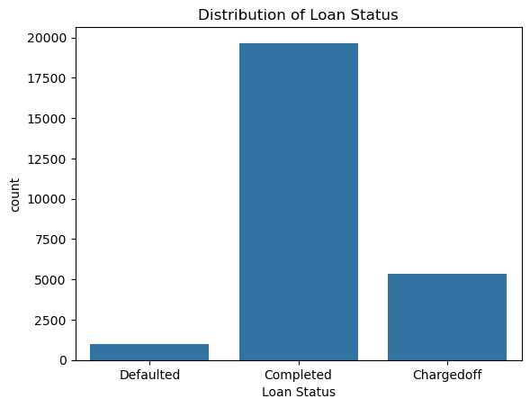

```python
# countplot to view the status of majority of the loans

color = sns.color_palette()[0]
sns.countplot(x = df.LoanStatus, color = color)
plt.xlabel('Loan Status')
plt.title("Distribution of Loan Status");
```

From the above bar chart, we can see that the majority of loans are completed in status while very few loans are defaulted.

Next, is the first feature, 'ProsperScore' that can affect the Loan Status.

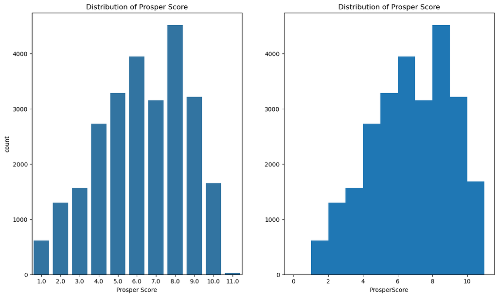

```python
# Bar chart and histogram to see the majority of the loans at higher or lower risk

plt.subplots(figsize=[14,8])

plt.subplot(1,2,1)

plt.title("Distribution of Prosper Score")

color = sns.color_palette()[0]
sns.countplot(x = df.ProsperScore, color = color)
plt.xlabel('Prosper Score')

plt.subplot(1,2,2)
plt.title("Distribution of Prosper Score")

binsize = 1
bins = np.arange(0, df['ProsperScore'].max()+binsize, binsize)

plt.hist(data = df, x = 'ProsperScore', bins = bins)
plt.xlabel('ProsperScore')
plt.show()
```

Next, is the second feature, 'EmploymentStatus'

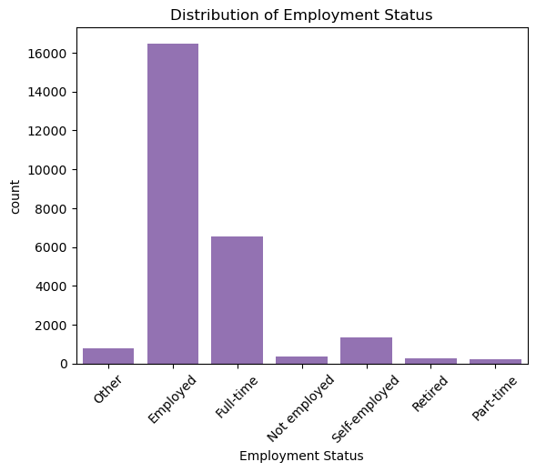

```python
# bar chart showing if the borrowers that are employed are more than the borrowers that are unemployed

color = sns.color_palette()[4]
sns.countplot(x = df['EmploymentStatus'], color = color)
plt.xticks(rotation = 45)
plt.title("Distribution of Employment Status")
plt.xlabel('Employment Status');
```

The bar chart above shows that the borrowers that are employed have the highest count of 16000 compared to the borrowers that are unemployed, having count of about 500.

Next, is the third feature, 'StatedMonthlyIncome'

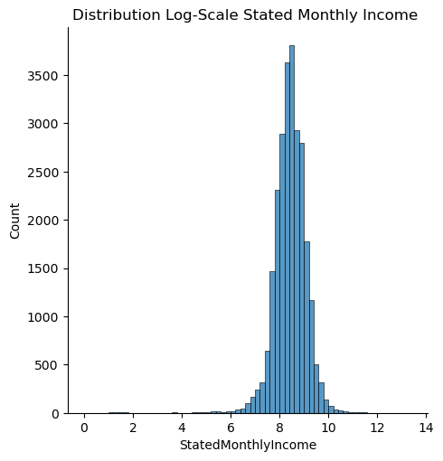

```python
# histogram showing the distribution of stated monthly income

x = np.log(df.StatedMonthlyIncome)
bins = np.arange(0, max(x)+0.2, 0.2)
sns.displot(df, x= x, bins = bins)

plt.title("Distribution Log-Scale Stated Monthly Income ")
plt.show();
```

This distribution of 'StatedMonthlyIncome' above is almost a normal distribution with most frequent occurence between 8 and 10 on a log scale

Next, is the fourth feature, 'BorrowerRate'

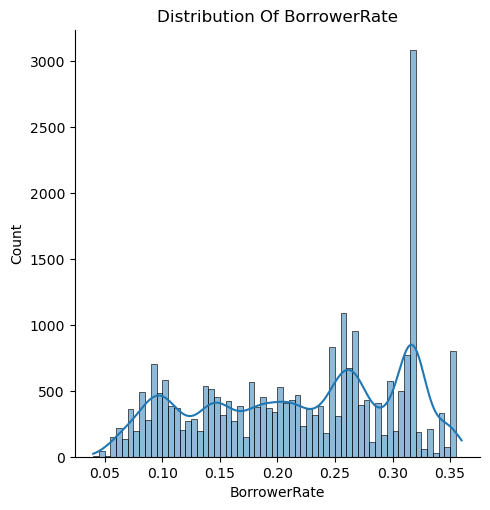

```python
# distribution of borrower rate

bins = np.arange(df['BorrowerRate'].min(), df['BorrowerRate'].max()+0.005, 0.005)
sns.displot(df, x = "BorrowerRate", bins = bins, kde=True)
plt.title("Distribution Of BorrowerRate");
```

This above distribution shows that there is a spike in the amount of loans at BorrowerRate of about 0.32 and the frequency quickly trails off until the next spike.

### Discuss the distribution(s) of your variable(s) of interest. Were there any unusual points? Did you need to perform any transformation?

I performed a log transform on the variable 'StatedMonthlyIncome,' and discovered that it is close to normal, with a peak between 8 and 10 log-scaled monthly income.

## Bivariate Exploration

To start off with, I want to look at the pairwise correlations present among features in the data.

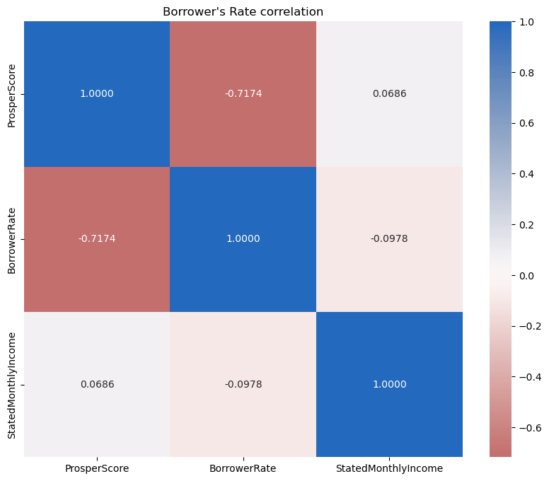

```python
# heatmap chart showing correlation among features

corr = df[['ProsperScore', 'BorrowerRate', 'StatedMonthlyIncome',
             'LoanStatus', 'EmploymentStatus']]

# correlation plot
plt.figure(figsize = [10, 8])
sns.heatmap(corr.corr(), annot = True, fmt = '.4f',
           cmap = 'vlag_r', center = 0)
plt.title("Borrower's Rate correlation");
```

The above data show a weak negative correlation between monthly income and borrower rate, as well as, a weak positive correlation between monthly income and Prosper Score. However, we can see a strong negative correlation between Borrower Rate and Prosper Score.

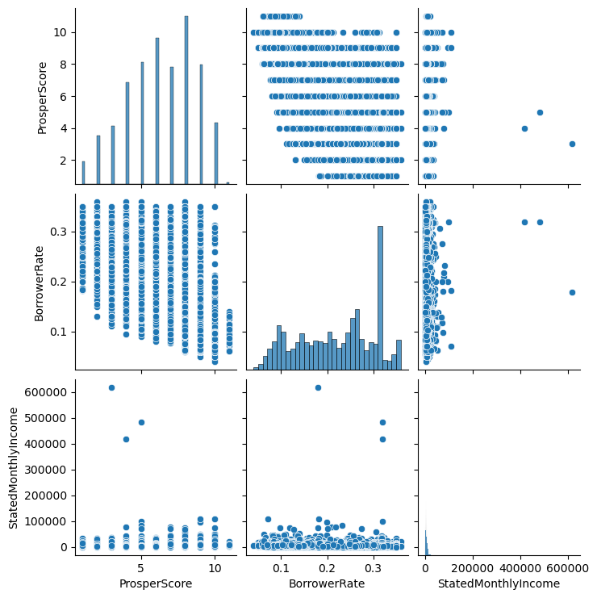

```python
# plot matrix: sample loans so that plots are clearer and
# they render faster

plt.figure(figsize=[12,5])
sns.pairplot(df[['ProsperScore', 'BorrowerRate', 'StatedMonthlyIncome',
                 'LoanStatus', 'EmploymentStatus']]);
```

According to the plots above, there is a strong negative correlation between ProsperScore and BorrowerRate. This means that an increase in one will result in a decrease in the other.

### Investigate the relationship between 'ProsperScore' and 'BorrowersRate'

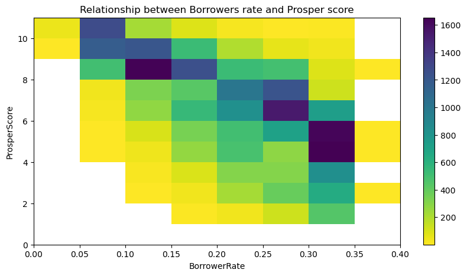

```python
# hist2d chart showing borrowers rate vs prosper score

bin_x = np.arange(0, df['BorrowerRate'].max()+0.05, 0.05)
bin_y = np.arange(0, df['ProsperScore'].max()+1, 1)

plt.figure(figsize=[10,5])
plt.hist2d(data = df, x = 'BorrowerRate', y = 'ProsperScore', bins = [bin_x, bin_y], cmap='viridis_r', cmin=0.5);
plt.colorbar()
plt.title('Relationship between Borrowers rate and Prosper score')
plt.xlabel('BorrowerRate')
plt.ylabel('ProsperScore');
```

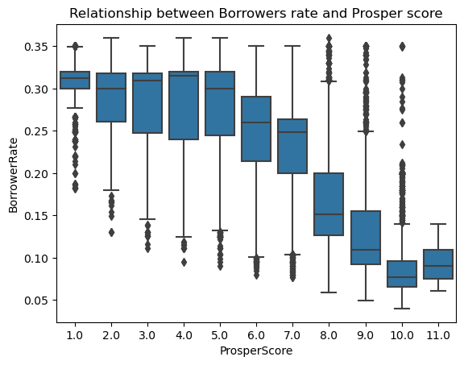

```python
# boxplot showing borrowers rate vs prosper score

color = sns.color_palette()[0]
sns.boxplot(data=df,x = "ProsperScore", y = "BorrowerRate", color = color)
plt.title('Relationship between Borrowers rate and Prosper score')
plt.show();
```

These plots above show that higher prosper score are attributed to lower borrower rate and vice versa.

### Relationship between Employment Status and Borrower Rate

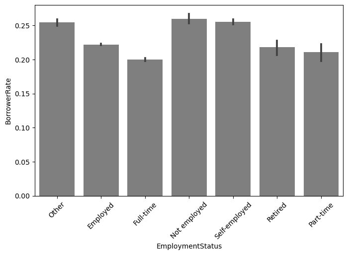

```python
# bar chart showing employment status and borrower rate

plt.figure(figsize=[8,5])
color = sns.color_palette()[7]
sns.barplot(data=df, x='EmploymentStatus', y='BorrowerRate', color=color);
plt.xticks(rotation=45);
```

From the above bar chart, we can observe that the employed borrowers are slightly lower (0.22) than the unmployed borrowers (0.25)

### Relationship between loan status and prosper risk scores

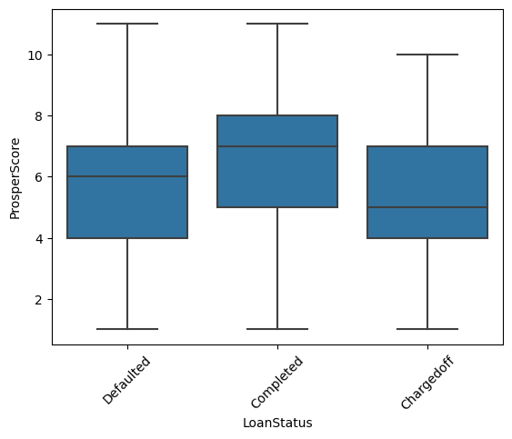

```python
# boxplot showing relationship between loan status and prosper risk scores

color = sns.color_palette()[0]
sns.boxplot(x = df['LoanStatus'], y = df['ProsperScore'], color = color)
plt.xticks(rotation=45);
```

The above boxplot shows that the defaulted loans have a risk score of 6, the completed loan have a risk score of 7 and the chargedoff loan have a risk score of 5.

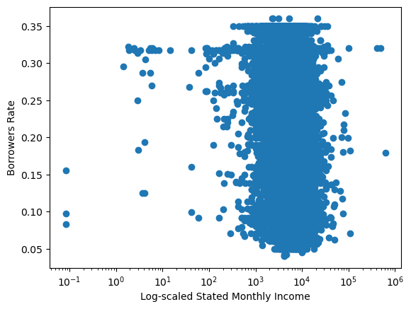

```python
# scatter plot showing relationship between loan status and employment status

plt.scatter(df.StatedMonthlyIncome, df.BorrowerRate)
plt.xscale("log")
plt.xlabel("Log-scaled Stated Monthly Income")
plt.ylabel("Borrowers Rate")
plt.show()
```

From the above chart, there is no significant positive or negative relationship between log-scaled Monthly income and Borrowers rate for a loan.

### Talk about some of the relationships you observed in this part of the investigation. How did the feature(s) of interest vary with other features in the dataset?

I obeserved a weak negative correlation between monthly income and borrower rate.

Also, a weak positive correlation between monthly income and Prosper Score.

A strong negative correlation between Borrower Rate and Prosper Score.

## Multivariate Exploration

### The relationship among the Loan Status , Prosper score and Employment status

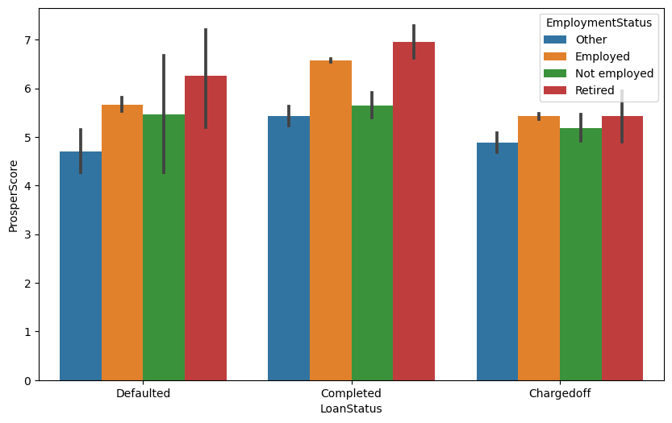

```python
# replacing individuals on partime, full time jobs and self employed as all employed
df2 = df.replace(['Full-time', 'Self-employed', 'Part-time'], 'Employed')

# combined barplot showing relationship among loan status, prosper score and employment status

plt.figure(figsize=[10, 6])

sns.barplot(data = df2, hue = 'EmploymentStatus', x = 'LoanStatus', y = 'ProsperScore');
```

### The relationship among borrower rate, Stated monthly income and prosper score

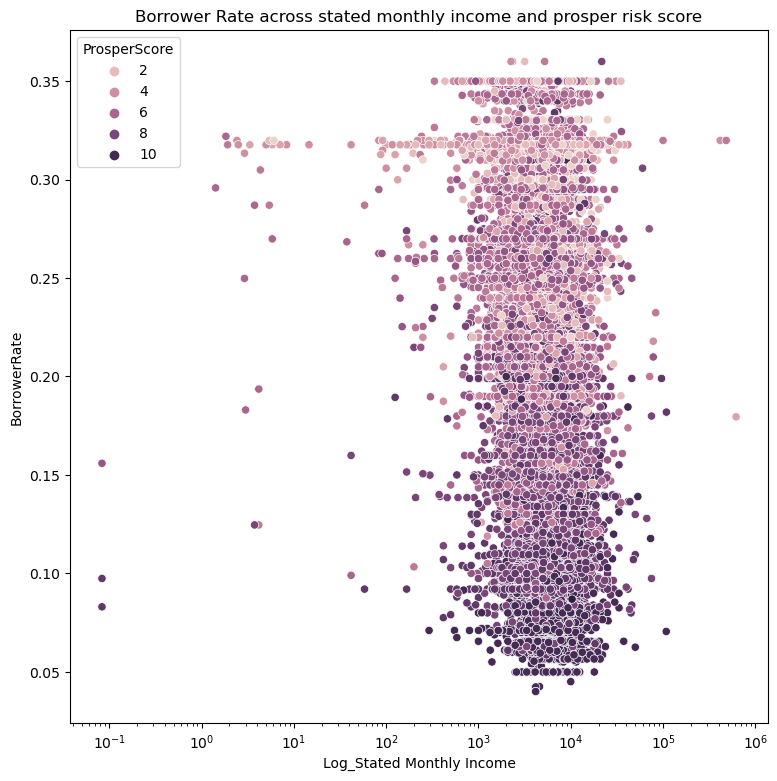

```python
# scatterplot sowing relationship among borrower rate, monthly income and prosper score

plt.figure(figsize=[9,9])
color = sns.color_palette()[1]
sns.scatterplot(data = df, hue = "ProsperScore", x = "StatedMonthlyIncome",y = "BorrowerRate", color=color)
plt.xscale("log")
plt.xlabel("Log_Stated Monthly Income")
plt.title("Borrower Rate across stated monthly income and prosper risk score");
```

From the above scatter plot, within a stated monthly income, we can observe low prosper score at high borrowers rate. This is an indicator of risky loans for lamost all income levels at high borrowers rate.

### The relationship among borrowers rate, prosper score and employment status

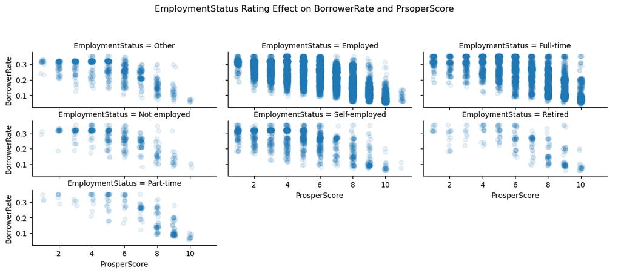

```python
# Employment status rating effect on relationship of BorrowerRate and PrsoperScore

g=sns.FacetGrid(data=df, aspect=1.2, height=3, col='EmploymentStatus', col_wrap=3)
g.map(sns.regplot, 'ProsperScore', 'BorrowerRate', x_jitter=0.1, scatter_kws={'alpha':0.1}, fit_reg=False);
g.add_legend();
g.fig.set_size_inches(12, 5)
g.fig.subplots_adjust(top=.8)
g.fig.suptitle('EmploymentStatus Rating Effect on BorrowerRate and PrsoperScore');
```

The above charts show that show that there is a strong negative correlation

## Conclusion

We can conclude that the prosper risk score is a significant factor in predicting the status and borrowers rate of a loan.